# Part II - Prosper Loans

## by Lucas Leal da Silva

## Investigation Overview

My main focus on this investigation was to understand the behavior of the borrowers regarding different characteristics when taking a loan, like income range and listing category.

## Dataset Overview

The dataset used was about 113,937 loans lent by the company Prosper, taken between 09/11/2005 and 10/03/2014. The original dataset included a total of 81 columns characterizing each loan, but I reduced it to 21 columns as a way to simplify the exploration of it, and focusing on the variables like date, borrower characterization, and other loan related variables like amount and status.

## Average Amount Lent per Year

The biggest influence of the average amount of money lent seems to be the year that the loan was created, as almost all of the ranges and categories had similar increases and decreases between the consecutive years.

Let's start by looking at how the **Average Amount** of money lent changes between the different years available in our dataset. We can see that in normal periods, the average amount lent increases from a year to the next one, but during the crisis period of 2007 and 2008, we have a drastic reduce in it, returning to raise back only from 2009 to 2010.

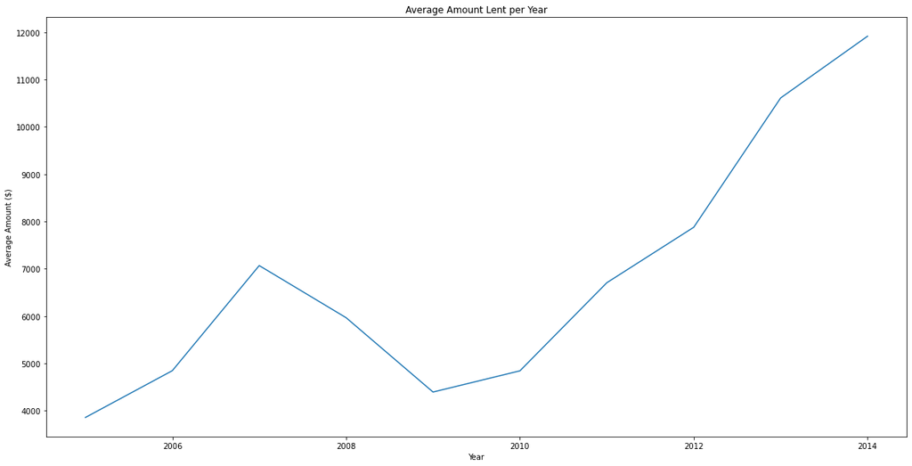

## Amount Lent by Category

We can see also that this trend is followed by the main categories (the ones present in almost every years). This is important because no a similar behavior between completely different categories shows that the year is globally affecting the data.

Also related by the category, we should investigate further why the average amount of money lent to "Not Available" category had a sudden raise after 2013.

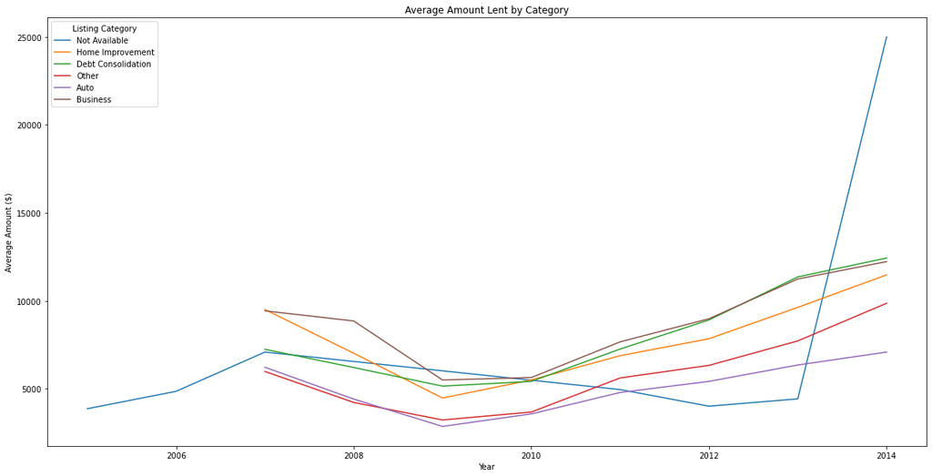

## Amount Lent by Income Range

Similar to the last visualization, now we will take a look on the behavior of the average amount lent per year by each income range. This shows us again that the main effect on the average is the year of the loan creation, as the different income ranges have almost parallels lines.

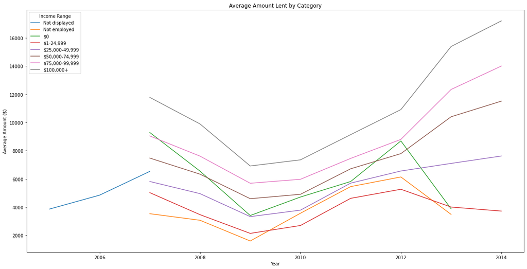